# Stat 480: Midterm solution

4/10/2020

## Tracking the Global Outbreak of COVID-19

The coronavirus pandemic has sickened more than 1.4 million people, according to official counts. Here, we will explore both the global and local growth of COVID-19 using data sourced on April 8th, 2020.

### Part I: Recovery data

This data set contains information on some of the first fully recovered cases of COVID-19. We will look at the time it took these patients to recover, defined as the number of days between a confirmed test and an official discharge date. The data is available at https://raw.githubusercontent.com/Stat480-at-ISU/Stat480-at-ISU.github.io/master/exams/data/covid19-recovered.csv

#### Question #1: An overview (5 pts)

1. Read the data without downloading the file locally.

```r
recovery_data <- readr::read_csv("https://raw.githubusercontent.com/Stat480-at-ISU/Stat480-at-ISU.github.io/master/exams/data/covid19-recovered.csv")
```

2. A first look:
   - What are the dimensions of the data?
   - What variables are included and what are their types?

```r
recovery_data %>% glimpse()
```

```
## Rows: 100
## Columns: 6
## $ confirmed  <chr> "1/23/2020", "1/24/2020", "1/24/2020", "1/25/2020", "1/27/…
## $ discharged <chr> "2020/2/19", "2020/2/7", "2020/2/21", "2020/2/12", "2020/2…
## $ recovery   <chr> "27 days", "14 days", "28 days", "18 days", "22 days", "24…
## $ category   <chr> "Imported", "Imported", "Imported", "Imported", "Imported"…
## $ age        <dbl> 66, 53, 37, 36, 56, 56, 35, 56, 56, 56, 31, 37, 73, 31, 47…
## $ gender     <dbl> 1, 0, 1, 1, 0, 1, 1, 0, 1, 1, 0, 0, 0, 1, 0, 1, 0, 0, 0, 0…
```

There are 100 observations of 6 variables. The variables included consist of 4 character variables (`confirmed`, `discharged`, `recovery`, and `category`), and 2 numeric variables (`age` and `gender`).

#### Question #2-3: Some wrangling (17 pts)

In order to continue with an analysis of this data, we should make some modifications to it.

1. Use functions from the `tidyverse` package to make the following modifications:
   - Convert the variables `confirmed` and `discharged` into variables of type “date”.
   - Extract the numeric value from the variable `recovery`.
   - Re-derive the variable `recovery` as the number of days between `confirmed` and `discharged` and save as `recovery_days`.
   - Convert the variable `category` from type `character` to type `factor`.
   - Save this data as `recovered` and use this data for the remaining questions in part I.

```r
recovered <- recovery_data %>%
  mutate(confirmed = mdy(confirmed),
         discharged = ymd(discharged),
         recovery = parse_number(recovery),
         category = factor(category),
         recovery_days = discharged - confirmed)
```

2. Look at a summary of the variables:

```r
recovered %>% summary()
```

```
##    confirmed            discharged            recovery         category
##  Min.   :2020-01-23   Min.   :2020-02-04   Min.   : 1.00   Imported:23
##  1st Qu.:2020-02-04   1st Qu.:2020-02-18   1st Qu.: 7.00   Local   :77
##  Median :2020-02-12   Median :2020-02-23   Median :11.00
##  Mean   :2020-02-11   Mean   :2020-02-24   Mean   :12.29
##  3rd Qu.:2020-02-17   3rd Qu.:2020-03-02   3rd Qu.:16.25
##  Max.   :2020-03-08   Max.   :2020-03-14   Max.   :31.00
##       age            gender    recovery_days
##  Min.   : 0.50   Min.   :0.0   Length:100
##  1st Qu.:34.75   1st Qu.:0.0   Class :difftime
##  Median :41.50   Median :1.0   Mode  :numeric
##  Mean   :42.53   Mean   :0.6
##  3rd Qu.:54.00   3rd Qu.:1.0
##  Max.   :79.00   Max.   :1.0
```

3. What was the longest amount of time someone represented in this data took to recover from COVID-19? Which observation was this? Use indexing to print this row of the data frame.

```r
max(recovered$recovery)
```

```
## [1] 31
```

```r
which.max(recovered$recovery)
```

```
## [1] 50
```

```r
recovered[which.max(recovered$recovery), ]
```

```
## # A tibble: 1 x 7
##   confirmed  discharged recovery category   age gender recovery_days
##   <date>     <date>        <dbl> <fct>    <dbl>  <dbl> <drtn>
## 1 2020-02-12 2020-03-14       31 Local       54      1 31 days
```

The longest amount of time someone represented in this data took to recover from COVID-19 was 31 days. This observation is found in row 50.

4. When was the first confirmed case in this data? Which observation is this? Use indexing to print this row of the data frame.

```r
min(recovered$confirmed)
```

```
## [1] "2020-01-23"
```

```r
which.min(recovered$confirmed)
```

```
## [1] 1
```

```r
recovered[which.min(recovered$confirmed), ]
```

```
## # A tibble: 1 x 7
##   confirmed  discharged recovery category   age gender recovery_days
##   <date>     <date>        <dbl> <fct>    <dbl>  <dbl> <drtn>
## 1 2020-01-23 2020-02-19       27 Imported    66      1 27 days
```

The first confirmed case in this data was on 2020-01-23. This observation is found in row 1.

#### Question #4: Time to recovery (16 pts)

If indeed infected, how long would it take for you to be free of the novel coronavirus?

1. Use `ggplot2` to look at the distribution of the variable `recovery` (you may need to adjust the size of the bins).

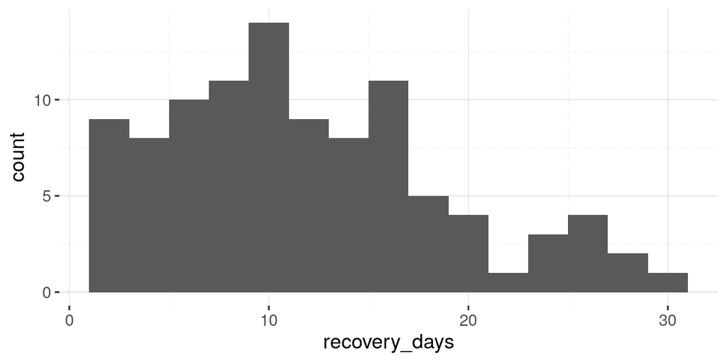

```r
ggplot(recovered) + geom_histogram(aes(recovery_days), binwidth = 2)
```

Most of the cases in this data recovered within 20 days of their confirmed test. A few of the cases in this data took close to 30 days to recover.

2. Is there a difference in the time it took to recover for different ages?
   - Create a new variable `age_blks` from `age` that introduces age categories that groups the ages of the patients into intervals: < 10, 10-20, 20-30, 30-40, 40-50, 50-60, 60-70, 70-80, and >80. (see ?cut).
   - Create side-by-side boxplots of the number of days to recovery for the different age groups.
   - Flip the coordinates and map the variable `age_blks` to the fill aesthetic.

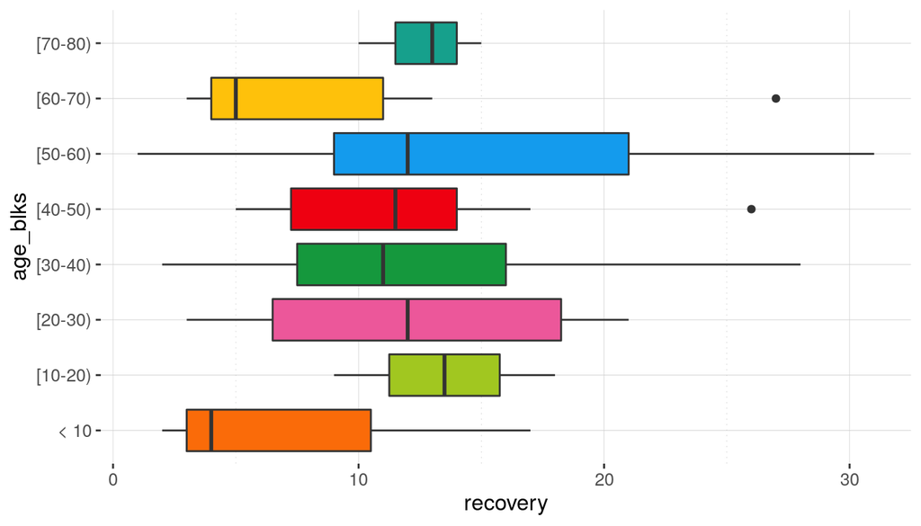

```r
recovered_ages <- recovered %>%
  mutate(age_blks = cut(age, c(0, 10, 20, 30, 40, 50, 60, 70, 80, 100),
                     labels = c("< 10", "[10-20)", "[20-30)", "[30-40)", "[40-50)", "[50-60)", "[60-70)", "[70-80)", ">= 80"), right = FALSE))

recovered_ages %>%
  ggplot() +
  geom_boxplot(aes(x = age_blks, y = recovery, fill = age_blks), show.legend = FALSE) +
  coord_flip()
```

While it is difficult to say much with any certainty given the small data set, there does not appear to be a large difference between the groups. The age group with the largest variability in the number of days it took to recover was the [50-60) age group. The 60-70 and < 10 age groups had the lowest median recovery time of around 5 days. The remaining groups had a median recovery time of around 11-13 days.

3. Is there a difference between the genders in the time it took to recover for any of the groups?
   - Use the age blocks created in the last question.
   - Create side-by-side boxplots for males and females (1’s and 0’s, respectively) for each of the age groups.
   - Fill your boxplots by mapping the variable `gender` to the aesthetic `fill`.

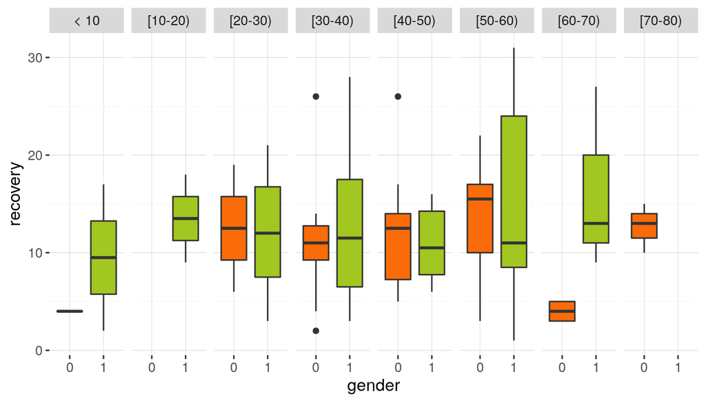

```r
recovered_ages %>%
  mutate(gender = factor(gender)) %>%
  ggplot() +
  geom_boxplot(aes(x = gender, y = recovery, fill = gender), show.legend = FALSE) +
  facet_grid(~age_blks)
```

The only age groups with much of a difference between genders are the <10 and 60-70 age groups. However, this difference is more likely due to a very small sample size rather than there being a true difference.

### Part II: Global Data

#### Question #1: First Overview (14 pts)

1. Read the data from https://raw.githubusercontent.com/Stat480-at-ISU/Stat480-at-ISU.github.io/master/exams/data/covid19-global.csv without downloading the file locally. Each line of the file contains daily counts for Province/State-County/Region pair.

```r
cases <- readr::read_csv("https://raw.githubusercontent.com/Stat480-at-ISU/Stat480-at-ISU.github.io/master/exams/data/covid19-global.csv")
```

2. How many rows and columns does the data have?

```r
dim(cases)
```

```
## [1] 263  81
```

This data contains 263 observations and 81 variables.

3. What are the variables called?

```r
#names(cases)
```

The variables are named `Province/State`, `Country/Region`, `Lat`, `Long`, and the dates `1/22/20` through `4/7/20`

4. Rename the variables `Province/State`, `Country/Region`, `Lat`, and `Long` to be `province`, `country`, `lat`, and `long`, respectively.

```r
names(cases)[1:4] <- c("province", "country", "lat", "long")
```

22. Each row contains data for one province-country pair. How many countries are represented in this data set?

```r
length(unique(cases$country))
```

```
## [1] 184
```

There are 184 countries represented in this data.

6. For each country represented, how many provinces are recorded? Print a table for the five countries with the largest number of provinces recorded.

```r
cases %>%
  group_by(country) %>%
  tally() %>%
  arrange(desc(n)) %>%
  slice(1:5)
```

```
## # A tibble: 5 x 2
##   country            n
##   <chr>          <int>
## 1 China             33
## 2 Canada            15
## 3 France            11
## 4 United Kingdom    11
## 5 Australia          8
```

China has the largest number of provinces recorded in this data with 33 provinces.

7. How many countries do not have any provinces recorded in this data?

```r
cases %>%
  count(country) %>%
  filter(n == 1) %>%
  tally()
```

```
## # A tibble: 1 x 1
##       n
##   <int>
## 1   177
```

In this instance we want to include the `NA`’s. If you look at the countries that contain provinces and an `NA` (there are 4 of them), the `NA` is referring to the mainland. Thus, in this data, there are 177 countries that do not have a province recorded here. In addition, if remove Diamond Princess and MS Zaandam cruise, there are actually 175 countries.

#### Question #2: Data wrangling (17 pts)

In order to continue with an analysis of this data, we should reshape it.

1. Use functions from the `tidyverse` package to modify the shape and form of the data:
   - Use a function from `dplyr` to remove the `lat` and `long` variables from the `cases` data.
   - Then use a function from the `tidyr` package to move from wide format into long format where each row represents the number of confirmed cases on a particular date for each country-province pair.
   - Lastly, use a function from `lubridate` to convert the variable `date` from a string into an object of type `date`.
   - Save the resulting data frame as `cases_long`.

```r
cases_long <- cases %>%
  select(-lat, -long) %>%
  pivot_longer(cols = -c(province, country),
               names_to = "date",
               values_to = "confirmed") %>%
  mutate(date = lubridate::mdy(date))
```

2. Identify the nine countries with the largest number of confirmed cases and save these in a data frame named `cases_by_country`. Plan of attack:
   - Begin with the data frame `cases_long`.
   - Calculate the number of confirmed cases for each country on each date.
   - Find the rank of the countries by current number of confirmed cases for each country.
   - Filter the top nine countries.
   - Save this data frame as `cases_by_country`.

```r
cases_by_country <- cases_long %>%
  group_by(date, country) %>%
  summarise(confirmed = sum(confirmed)) %>%
  group_by(country) %>%
  mutate(total = max(confirmed)) %>%
  ungroup() %>%
  mutate(rank = dense_rank(desc(total))) %>%
  filter(rank < 10)

cases_by_country %>% arrange(desc(date), desc(total)) %>% slice(1:9) %>% select(rank, country, total)
```

```
## # A tibble: 9 x 3
##    rank country         total
##   <int> <chr>           <dbl>
## 1     1 US             396223
## 2     2 Spain          141942
## 3     3 Italy          135586
## 4     4 France         110065
## 5     5 Germany        107663
## 6     6 China           82718
## 7     7 Iran            62589
## 8     8 United Kingdom  55949
## 9     9 Turkey          34109
```

The nine countries with the greatest number of total cases: US, Spain, Italy, France, Germany, China, Iran, United Kingdom, Turkey.

#### Question #3: Growth over time (15 pts)

1. Let’s look at how the number confirmed cases for these nine countries grew over time.
   - Start with the data frame `cases_by_country.`
   - Use `ggplot2` to plot the number of confirmed cases for each of the nine countries over time.
   - Map the variable `country` to color and use the function `fct_reorder2()` from the `forcats` package to align the colors of the lines with the colors in the legend.
   - Optional: to make the y-axis labels more readable, add the layer `+ scale_y_continuous(labels = scales::comma)`.

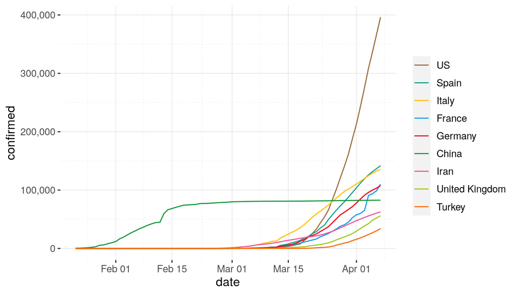

```r
ggplot(cases_by_country) +
  geom_line(aes(x = date, y = confirmed, color = forcats::fct_reorder2(country, date, confirmed))) +
  scale_y_continuous(labels = scales::comma)
```

Most countries have seen a considerable increase in the number of cases since mid-March - the exception to this case is China whose number of cases leveled off mid-February. The US has by far the largest number of cases and has yet to begin to level off like most of the other countries have.

2. Let’s next look at the difference the last week of March made (Mar 24 vs. Mar 31).
   - Use `ggplot2` to create a barchart of the number of cases for the top nine countries for the two dates, sorted according to the total number of cases in that country.
   - Make sure the labels of the bars are readable and fill by country.

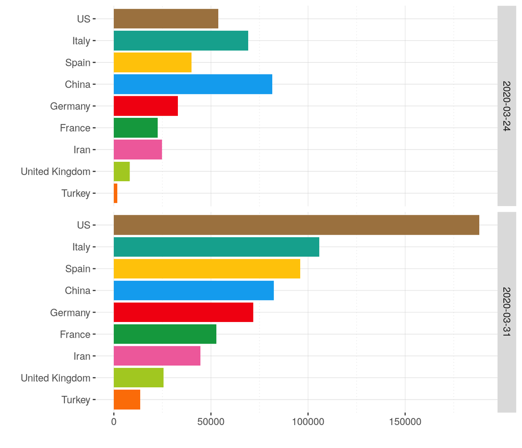

```r
cases_by_country %>%
  filter(date == "2020-03-31" | date == "2020-03-24") %>%
  mutate(country = forcats::fct_reorder(country, confirmed, .fun = max)) %>%
  ggplot() +
  geom_bar(aes(x = country, weight = confirmed, fill = country), show.legend = FALSE) +
  facet_grid(date~.) +
  coord_flip() +
  labs(x="", y="")
```

The number of cases in the US increased dramatically over the last week in March. Other countries that saw a substantial increase include Spain, Germany, Italy, and France.

#### Question #4: Some summaries (16 pts + 3 extra credit pts)

1. How many days did it take for each of the nine countries to go from their 500th case to their 20,000th case?

```r
cases_by_country %>%
  filter(confirmed >= 500) %>%
  group_by(country) %>%
  arrange(date) %>%
  summarise(min_value = confirmed[which.min(confirmed)],
            max_value = first(confirmed[confirmed>=20000]),
            date_first=date[which.min(confirmed)],
            date20k=date[first(which(confirmed>=20000))],
            days_to_20k = date20k - date_first) %>%
  select(country, days_to_20k) %>%
  arrange(days_to_20k)
```

```
## # A tibble: 9 x 2
##   country        days_to_20k
##   <chr>          <drtn>
## 1 China          13 days
## 2 Spain          13 days
## 3 Turkey         13 days
## 4 US             13 days
## 5 Germany        15 days
## 6 Italy          16 days
## 7 France         17 days
## 8 United Kingdom 17 days
## 9 Iran           21 days
```

Spain, China, Turkey, and the US went from 500 to 20,000 cases in the shortest amount of time – 13 days. Germany took 15 days, Italy 16 days, France and the UK 17 days, and Iran 21 days.

2. Let’s take another look at how the number of cases has grown. This time, though, let’s look at the growth for each country starting at their 100th case.
   - For each country, calculate the first date that the country had 100 or more cases.
   - Introduce a new variable that transforms the date variable into the number of days since the 100th case.
   - Save this data frame as `cases100`.
   - Create a subset of the `cases100` that contains only the last date and save as `cases100_last`.
   - Extra credit: Using `cases100` and `cases100_last`, recreate the visualization below.

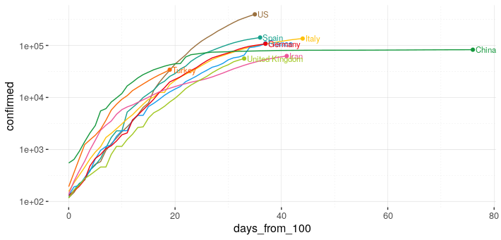

Create the 2 data frames:

```r
cases100 <- cases_by_country %>%
  filter(confirmed >= 100) %>%
  group_by(country) %>%
  arrange(date) %>%
  mutate(date100 = date[which.min(confirmed)],
          days_from_100 = (date100 %--% date)/ddays(1))

cases100_last <- filter(cases100, date == max(cases100$date))
```

Re-create the visualization:

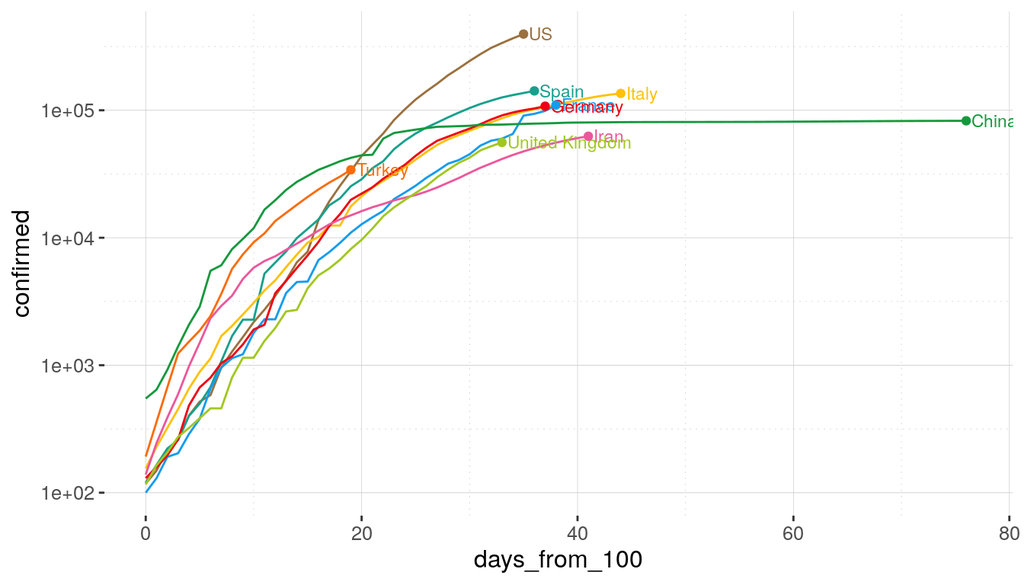

```r
cases100 %>%
  ggplot(aes(x = days_from_100, y = confirmed, color = forcats::fct_reorder2(country, date, confirmed))) +
  geom_line() +
  geom_text(data = cases100_last, aes(label = country, x = days_from_100 + 0.5), hjust = "left", size = 3) +
  geom_point(data = cases100_last) +
  scale_y_log10() +
  guides(color = FALSE)
```

This visualization appears to show that (assuming no issues in testing and reporting) growth rate has, fortunately, slowed for all nine countries included here.